# DecisionTree

Mike

2020/4/6

# Reference

### Main Concept

1. [决策树（decision tree）(一)——构造决策树方法](https://blog.csdn.net/u012328159/article/details/70184415)
2. [决策树（decision tree）(二)——剪枝](https://blog.csdn.net/u012328159/article/details/79285214)
3. [决策树（decision tree）(三)——连续值处理](https://blog.csdn.net/u012328159/article/details/79396893)
4. [决策树（decision tree）（四）——缺失值处理](https://blog.csdn.net/u012328159/article/details/79413610)
5. [HOW DECISION TREE ALGORITHM WORKS](http://dataaspirant.com/2017/01/30/how-decision-tree-algorithm-works/)

### ID3

1. [分类算法 – 决策树ID3算法](https://blog.csdn.net/weixin_43216017/article/details/87474045)
2. [ID3 Algorithm & ROC Analysis](https://www.slideshare.net/talhakabakus/id3-algorithm-roc-analysis-14984288)

### C4.5

1. [决策树建树原理之C4.5和C5.0以及CART建树原理（二](https://blog.csdn.net/weixin_44835596/article/details/89852921)

### CART

1. [Decision Tree 決策樹 | CART, Conditional Inference Tree, RandomForest](https://www.jamleecute.com/decision-tree-cart-%E6%B1%BA%E7%AD%96%E6%A8%B9/)
2. [CART 分類與回歸樹](https://www.itread01.com/content/1509178954.html)

### CHAID

1. [IBM SPSS Modeler算法系列–决策树CHAID算法](https://www.cda.cn/view/20421.html)
2. [卡方自動互動檢測](https://www.newton.com.tw/wiki/%E5%8D%A1%E6%96%B9%E8%87%AA%E5%8B%95%E4%BA%92%E5%8B%95%E6%AA%A2%E6%B8%AC/21125021)
3. [CHAID and R – When you need explanation – May 15, 2018](https://www.r-bloggers.com/chaid-and-r-when-you-need-explanation-may-15-2018/)

### C50

1. [IBM SPSS Modeler算法系列—–决策树C5.0算法](https://blog.csdn.net/chenjunji123456/article/details/52189312?depth_1-utm_source=distribute.pc_relevant.none-task-blog-OPENSEARCH-12&utm_source=distribute.pc_relevant.none-task-blog-OPENSEARCH-12)

### Code

1. [决策树ID3原理及R语言python代码实现（西瓜书）](https://www.bbsmax.com/A/ke5jv4wy5r/)
2. [R语言：决策树ID3/C4.5/CART/C5.0算法的实现](https://blog.csdn.net/weixin_43216017/article/details/87739323)
3. [NTU CINC : R軟體資料探勘實務(上)–分類模型](http://www.cc.ntu.edu.tw/chinese/epaper/0034/20150920_3410.html)
4. [Generate ROC Curve Charts for Print and Interactive Use](https://cran.r-project.org/web/packages/plotROC/vignettes/examples.html)
5. 決策樹(Decision Tree)以及隨機森林(Random Forest)介紹
6. [卡方自動交叉檢驗 (CHAID)](https://rpubs.com/jiankaiwang/chaid)
7. [Determining Creditworthiness for Loan Applications Using C5.0 Decision Trees](https://rpubs.com/cyobero/C50)
8. [Package ‘C50’](https://cran.r-project.org/web/packages/C50/C50.pdf)

### Others

1. [機器學習：決策樹總結｜ID3 C4.5/C5.0 CHAID CART與QUEST](https://kknews.cc/zh-tw/tech/m36obez.html)
2. [Regression Tree | 迴歸樹, Bagging, Bootstrap Aggregation | R語言](https://www.jamleecute.com/regression-tree-%E8%BF%B4%E6%AD%B8%E6%A8%B9-bagging-bootstrap-aggrgation-r%E8%AA%9E%E8%A8%80/)
3. [rpart 决策树中的 Cp（complexity parameter）参数](https://blog.csdn.net/a8131357leo/article/details/89529677)
4. [Meaning of Surrogate Split](https://stats.stackexchange.com/questions/171574/meaning-of-surrogate-split)
5. [消除誤差修剪法 Reduced error pruning (REP)](http://123android.blogspot.com/2011/11/111027-data-mining.html)
6. [C4.5 Pessimistic Error Pruning，PEP](http://gitlinux.net/2019-06-04-C45/)

# Algorithm

| Algorithm | Explainatory Var. Type | Feature Selection | Pruning Rule | Missing Value |
| --- | --- | --- | --- | --- |
| ID3 | Discrete | Entropy, Information Gain | Predicted ER | Not Allowed |
| C4.5 | Discrete, Bi-partition | Entropy, IV, Gain Ratio | **PEP, REP** | Allowed |
| CHAID | Discrete, Ch-Merge | Chisquare Test p value | No Pruning | ? |
| CART | Continuous | Gini Index, MSE | Predicted ER | ? |
| QUEST | ? | Chisquare / F Test p value | Predicted ER | ? |
| C5.0 | Discrete, Bi-partition | Gain Ratio, PRISM?, Boosting? | PEP | ? |
| PUBLIC | ? | ? | ? | ? |
| SLIQ | ? | ? | ? | ? |
| SPRINT | ? | ? | ? | ? |

# Packages & Functions

```r
library(magrittr) # %<>%
library(dplyr) # data manipulation
library(rpart) # ID3, CART
# library(RWeka) # C4.5(J48)
# library(C50) # C5.0
```

## Partition Data

Ramdomly partition data into Training and Testing

```r
Partition = function(data, train_proportion = 0.9){
  train_index = sample(x = nrow(data),
                       size = train_proportion*nrow(data),
                       replace = FALSE )
  train_data = data[train_index,]
  test_data = data[-train_index,]
  return(
    list(
      training = train_data,
      testing = test_data
      )
    )
}
```

## Model Performance

```r
ModelPerformance <- function(predict_condition, true_condition){

  require(dplyr)
  require(tidyr)
  require(ggplot2)

  # Confusion Matrix, Contingency Table
  confusion_matrix <- table(predict_condition, true_condition)

  if(identical(dim(confusion_matrix), as.integer(c(2,2)))){

    # 2x2 confusion matrix --------------------------------

    # Hit, True Positive
    TP <-  confusion_matrix[1,1]
    # Correct Rejection, True Negative
    TN <- confusion_matrix[2,2]
    # False Alarm, Type I Error, False Positive
    FP <-  confusion_matrix[1,2]
    # Miss, Type II Error, False Negative
    FN <-  confusion_matrix[2,1]



    # Sensitivity, Recall, True Positive Rate
    TPR <- TP / (TP + FN)

    # Specificity, Selectivity, True Negative Rate
    TNR <- TN / (TN + FP)

    # Precision, Positive Predictive Value
    PPV <- TP / (TP + FP)

    # Negative Prediction Value
    NPV <- TN / (TN + FN)

    # Miss Rate, False Negative Rate
    FNR <- FN /(FN + TP)

    # Fall Out, False Positive Rate
    FPR <-  FP / (FP + TN)

    # False Discovery Rate
    FDR <- FP / (FP + TP)

    # False Omission Rate
    FOR <- FN / (FN + TN)



    # Threat Score, Critical Success Index
    TS <- TP / (TP + FN + FP)

    # Accuracy
    ACC <- (TP + TN) / sum(confusion_matrix)

    # Balanced Accuracy, Harmonic Mean of Precision and Sensitivity
    BA <- (TPR + TNR) / 2

    # F1 Score
    F1 <- 2*(PPV*TPR)/(PPV+TPR)

    # Matthews correlation coefficient
    MCC <- (TP*TN -FP*FN) / (sqrt(TP+FP)*sqrt(TP+FN)*sqrt(TN+FP)*sqrt(TN+FN))

    # Bookmaker Informedness
    BM <- TPR + TNR - 1

    # Markedness, delta-P
    MK <- PPV + NPV - 1

    df = data.frame(
          TPR = TPR,
          TNR = TNR,
          PPV = PPV,
          NPV = NPV,
          FNR = FNR,
          FPR = FPR,
          FDR = FDR,
          FOR = FOR,
          TS = TS,
          ACC = ACC,
          BA = BA,
          F1 = F1,
          MCC = MCC,
          BM = BM,
          MK = MK
        )


    positive_measure = df[c('TPR', 'TNR', 'PPV', 'NPV', 'F1',
                            'ACC', 'TS', 'BA', "BM", 'MK')]%>% gather

    plot_positive <-  ggplot(positive_measure,
         aes(x=reorder(key,-value),y=value,fill=key))+
          geom_bar(stat="identity")+
          # coord_polar(theta="x",direction=1)+
          labs(x="Measure",y="Performance")+
          theme(legend.position="bottom",legend.box="horizontal")+
          ggtitle(label = 'Positive Model Performance',
                  subtitle = 'The higher, the better.')+
          geom_text(aes(x = reorder(key,-value),
                              y=value,
                              label = round(value, 2)),
                    vjust = 1.2)


    negative_measure = df[c("FNR", "FPR", "FDR", "FOR")]%>% gather

    plot_negative <- ggplot(negative_measure,
         aes(x=reorder(key,-value),y=value,fill=key))+
          geom_bar(stat="identity")+
          # coord_polar(theta="x",direction=1)+
          labs(x="Measure",y="Performance")+
          theme(legend.position="bottom",legend.box="horizontal")+
          ggtitle(label = 'Negative Model Performance',
                  subtitle = 'The lower, the better.')+
          geom_text(aes(x = reorder(key,-value),
                              y=value,
                              label = round(value, 2)),
                    vjust = 1.2)


    return(
      list(
        confusion_matrix = confusion_matrix,
        TP = TP,
        TN = TN,
        FP = FP,
        FN = FN,

        TPR = TPR,
        TNR = TNR,
        PPV = PPV,
        NPV = NPV,
        FNR = FNR,
        FPR = FPR,
        FDR = FDR,
        FOR = FOR,
        TS = TS,
        ACC = ACC,
        BA = BA,
        F1 = F1,
        MCC = MCC,
        BM = BM,
        MK = MK,

        df = df,
        plot_positive = plot_positive,
        plot_negative = plot_negative
      )
    )
  }else if(identical(dim(confusion_matrix), as.integer(c(3,3)))){
    # 3x3 confusion matrix --------------------------------

    # Accuracy
    ACC = sum(diag(confusion_matrix))/sum(confusion_matrix)


    return(
      list(
        confusion_matrix = confusion_matrix,
        ACC = ACC
      )
    )

  }

}
```

# Dataset

## 1. iris

### Summary

```r
# Raw Data
iris %>% DT::datatable()
```

|  | Sepal.Length | Sepal.Width | Petal.Length | Petal.Width | Species |
| --- | --- | --- | --- | --- | --- |
| 1 | 5.1 | 3.5 | 1.4 | 0.2 | setosa |
| 2 | 4.9 | 3 | 1.4 | 0.2 | setosa |
| 3 | 4.7 | 3.2 | 1.3 | 0.2 | setosa |
| 4 | 4.6 | 3.1 | 1.5 | 0.2 | setosa |
| 5 | 5 | 3.6 | 1.4 | 0.2 | setosa |
| 6 | 5.4 | 3.9 | 1.7 | 0.4 | setosa |
| 7 | 4.6 | 3.4 | 1.4 | 0.3 | setosa |
| 8 | 5 | 3.4 | 1.5 | 0.2 | setosa |
| 9 | 4.4 | 2.9 | 1.4 | 0.2 | setosa |
| 10 | 4.9 | 3.1 | 1.5 | 0.1 | setosa |

[output cut: 140 more lines]

```r
# Check Variabl Type
iris %>% str()
```

```
## 'data.frame':    150 obs. of  5 variables:
##  $ Sepal.Length: num  5.1 4.9 4.7 4.6 5 5.4 4.6 5 4.4 4.9 ...
##  $ Sepal.Width : num  3.5 3 3.2 3.1 3.6 3.9 3.4 3.4 2.9 3.1 ...
##  $ Petal.Length: num  1.4 1.4 1.3 1.5 1.4 1.7 1.4 1.5 1.4 1.5 ...
##  $ Petal.Width : num  0.2 0.2 0.2 0.2 0.2 0.4 0.3 0.2 0.2 0.1 ...
##  $ Species     : Factor w/ 3 levels "setosa","versicolor",..: 1 1 1 1 1 1 1 1 1 1 ...
```

```r
# Check Missing Value
is.na(iris) %>% DT::datatable()
```

| Sepal.Length | Sepal.Width | Petal.Length | Petal.Width | Species |
| --- | --- | --- | --- | --- |
| False | False | False | False | False |
| False | False | False | False | False |
| False | False | False | False | False |
| False | False | False | False | False |
| False | False | False | False | False |
| False | False | False | False | False |
| False | False | False | False | False |
| False | False | False | False | False |
| False | False | False | False | False |
| False | False | False | False | False |

[output cut: 140 more lines]

```r
is.na(iris) %>% sum()
```

```
## [1] 0
```

```r
# Check Imbalence Data
table(iris$Species)
```

```
##
##     setosa versicolor  virginica
##         50         50         50
```

```r
# Check Distribution
summary(iris)
```

```
##   Sepal.Length    Sepal.Width     Petal.Length    Petal.Width
##  Min.   :4.300   Min.   :2.000   Min.   :1.000   Min.   :0.100
##  1st Qu.:5.100   1st Qu.:2.800   1st Qu.:1.600   1st Qu.:0.300
##  Median :5.800   Median :3.000   Median :4.350   Median :1.300
##  Mean   :5.843   Mean   :3.057   Mean   :3.758   Mean   :1.199
##  3rd Qu.:6.400   3rd Qu.:3.300   3rd Qu.:5.100   3rd Qu.:1.800
##  Max.   :7.900   Max.   :4.400   Max.   :6.900   Max.   :2.500
##        Species
##  setosa    :50
##  versicolor:50
##  virginica :50
##
##
##
```

### Conclusion

- Data : iris (in R)
- Explained Var (Y) : Category (Species)
- Explainatory Var (X) : Continuous
- Missing Value: 0

Recommended Algorithm: **CART**

## 2. Titanic

Titanic in R seems to be an aggregation data, not raw data.

```r
data('Titanic')
class(Titanic)
```

```
## [1] "table"
```

```r
Titanic
```

```
## , , Age = Child, Survived = No
##
##       Sex
## Class  Male Female
##   1st     0      0
##   2nd     0      0
##   3rd    35     17
##   Crew    0      0
##
## , , Age = Adult, Survived = No
##
##       Sex
## Class  Male Female
##   1st   118      4
##   2nd   154     13
##   3rd   387     89
##   Crew  670      3
##
## , , Age = Child, Survived = Yes
##
##       Sex
## Class  Male Female
##   1st     5      1
##   2nd    11     13
##   3rd    13     14
##   Crew    0      0
##
## , , Age = Adult, Survived = Yes
##
##       Sex
## Class  Male Female
##   1st    57    140
##   2nd    14     80
##   3rd    75     76
##   Crew  192     20
```

### Rawdata

```r
Titanic_df = data.frame(Titanic)
repeating_sequence <- rep(1:nrow(Titanic_df), Titanic_df$Freq)
Titanic_raw <- Titanic_df[repeating_sequence,]
Titanic_raw$Freq <- NULL # delete Freq column

nrow(Titanic_df) # Titanic is an aggregation data
```

```
## [1] 32
```

```r
nrow(Titanic_raw)
```

```
## [1] 2201
```

```r
DT::datatable(Titanic_raw)
```

|  | Class | Sex | Age | Survived |
| --- | --- | --- | --- | --- |
| 3 | 3rd | Male | Child | No |
| 3.1 | 3rd | Male | Child | No |
| 3.2 | 3rd | Male | Child | No |
| 3.3 | 3rd | Male | Child | No |
| 3.4 | 3rd | Male | Child | No |
| 3.5 | 3rd | Male | Child | No |
| 3.6 | 3rd | Male | Child | No |
| 3.7 | 3rd | Male | Child | No |
| 3.8 | 3rd | Male | Child | No |
| 3.9 | 3rd | Male | Child | No |

[output cut: 2191 more lines]

### Summary

```r
# Check Variabl Type
Titanic_raw %>% str()
```

```
## 'data.frame':    2201 obs. of  4 variables:
##  $ Class   : Factor w/ 4 levels "1st","2nd","3rd",..: 3 3 3 3 3 3 3 3 3 3 ...
##  $ Sex     : Factor w/ 2 levels "Male","Female": 1 1 1 1 1 1 1 1 1 1 ...
##  $ Age     : Factor w/ 2 levels "Child","Adult": 1 1 1 1 1 1 1 1 1 1 ...
##  $ Survived: Factor w/ 2 levels "No","Yes": 1 1 1 1 1 1 1 1 1 1 ...
```

```r
# Check Missing Value
is.na(Titanic_raw) %>% sum()
```

```
## [1] 0
```

```r
# Check Imbalence Data
table(Titanic_raw$Survived)
```

```
##
##   No  Yes
## 1490  711
```

```r
# Check Distribution
summary(Titanic_raw)
```

```
##   Class         Sex          Age       Survived
##  1st :325   Male  :1731   Child: 109   No :1490
##  2nd :285   Female: 470   Adult:2092   Yes: 711
##  3rd :706
##  Crew:885
```

### Conclusion

- Data : Titanic (in R)
- Explained Var (Y) : Category (Survived)
- Explainatory Var (X) : Category
- Missing Value: 0

Recommended Algorithm: **ID3**

## 3. Breast Cancer

### Raw Data

Source : [UCI : Breast Cancer Data Set](http://archive.ics.uci.edu/ml/datasets/breast+cancer)

```r
BreastCancer <-  read.csv('http://archive.ics.uci.edu/ml/machine-learning-databases/breast-cancer/breast-cancer.data', header = FALSE)

DT::datatable(BreastCancer)
```

|  | V1 | V2 | V3 | V4 | V5 | V6 | V7 | V8 | V9 | V10 |
| --- | --- | --- | --- | --- | --- | --- | --- | --- | --- | --- |
| 1 | no-recurrence-events | 30-39 | premeno | 30-34 | 0-2 | no | 3 | left | left_low | no |
| 2 | no-recurrence-events | 40-49 | premeno | 20-24 | 0-2 | no | 2 | right | right_up | no |
| 3 | no-recurrence-events | 40-49 | premeno | 20-24 | 0-2 | no | 2 | left | left_low | no |
| 4 | no-recurrence-events | 60-69 | ge40 | 15-19 | 0-2 | no | 2 | right | left_up | no |
| 5 | no-recurrence-events | 40-49 | premeno | 0-4 | 0-2 | no | 2 | right | right_low | no |
| 6 | no-recurrence-events | 60-69 | ge40 | 15-19 | 0-2 | no | 2 | left | left_low | no |
| 7 | no-recurrence-events | 50-59 | premeno | 25-29 | 0-2 | no | 2 | left | left_low | no |
| 8 | no-recurrence-events | 60-69 | ge40 | 20-24 | 0-2 | no | 1 | left | left_low | no |
| 9 | no-recurrence-events | 40-49 | premeno | 50-54 | 0-2 | no | 2 | left | left_low | no |
| 10 | no-recurrence-events | 40-49 | premeno | 20-24 | 0-2 | no | 2 | right | left_up | no |

[output cut: 276 more lines]

### Summary

```r
BreastCancer.Names <-  readLines('http://archive.ics.uci.edu/ml/machine-learning-databases/breast-cancer/breast-cancer.names')
BreastCancer.Names
```

```
##  [1] "Citation Request:"
##  [2] "   This breast cancer domain was obtained from the University Medical Centre,"
##  [3] "   Institute of Oncology, Ljubljana, Yugoslavia.  Thanks go to M. Zwitter and "
##  [4] "   M. Soklic for providing the data.  Please include this citation if you plan"
##  [5] "   to use this database."
##  [6] ""
##  [7] "1. Title: Breast cancer data (Michalski has used this)"
##  [8] ""
##  [9] "2. Sources: "
## [10] "   -- Matjaz Zwitter & Milan Soklic (physicians)"
## [11] "      Institute of Oncology "
## [12] "      University Medical Center"
## [13] "      Ljubljana, Yugoslavia"
## [14] "   -- Donors: Ming Tan and Jeff Schlimmer (Jeffrey.Schlimmer@a.gp.cs.cmu.edu)"
## [15] "   -- Date: 11 July 1988"
```

[output cut: 58 more lines]

### Set Column Name

```r
BC_colnames <- c("Class", "age", "menopause", "tumor-size","inv-nodes",
                 "node-caps", "deg-malig", "breast", "breast-quad", "irradiate")

colnames(BreastCancer) <- BC_colnames

# Check Column Name
DT::datatable(BreastCancer)
```

|  | Class | age | menopause | tumor-size | inv-nodes | node-caps | deg-malig | breast | breast-quad | irradiate |
| --- | --- | --- | --- | --- | --- | --- | --- | --- | --- | --- |
| 1 | no-recurrence-events | 30-39 | premeno | 30-34 | 0-2 | no | 3 | left | left_low | no |
| 2 | no-recurrence-events | 40-49 | premeno | 20-24 | 0-2 | no | 2 | right | right_up | no |
| 3 | no-recurrence-events | 40-49 | premeno | 20-24 | 0-2 | no | 2 | left | left_low | no |
| 4 | no-recurrence-events | 60-69 | ge40 | 15-19 | 0-2 | no | 2 | right | left_up | no |
| 5 | no-recurrence-events | 40-49 | premeno | 0-4 | 0-2 | no | 2 | right | right_low | no |
| 6 | no-recurrence-events | 60-69 | ge40 | 15-19 | 0-2 | no | 2 | left | left_low | no |
| 7 | no-recurrence-events | 50-59 | premeno | 25-29 | 0-2 | no | 2 | left | left_low | no |
| 8 | no-recurrence-events | 60-69 | ge40 | 20-24 | 0-2 | no | 1 | left | left_low | no |
| 9 | no-recurrence-events | 40-49 | premeno | 50-54 | 0-2 | no | 2 | left | left_low | no |
| 10 | no-recurrence-events | 40-49 | premeno | 20-24 | 0-2 | no | 2 | right | left_up | no |

[output cut: 276 more lines]

### Alter Variable Type

```r
# To change numeric value into factor, it should be transferred to chracter first !
BreastCancer$`deg-malig` %<>% as.character() %>% as.factor()

# Check Type Again
str(BreastCancer)
```

```
## 'data.frame':    286 obs. of  10 variables:
##  $ Class      : Factor w/ 2 levels "no-recurrence-events",..: 1 1 1 1 1 1 1 1 1 1 ...
##  $ age        : Factor w/ 6 levels "20-29","30-39",..: 2 3 3 5 3 5 4 5 3 3 ...
##  $ menopause  : Factor w/ 3 levels "ge40","lt40",..: 3 3 3 1 3 1 3 1 3 3 ...
##  $ tumor-size : Factor w/ 11 levels "0-4","10-14",..: 6 4 4 3 1 3 5 4 11 4 ...
##  $ inv-nodes  : Factor w/ 7 levels "0-2","12-14",..: 1 1 1 1 1 1 1 1 1 1 ...
##  $ node-caps  : Factor w/ 3 levels "?","no","yes": 2 2 2 2 2 2 2 2 2 2 ...
##  $ deg-malig  : Factor w/ 3 levels "1","2","3": 3 2 2 2 2 2 2 1 2 2 ...
##  $ breast     : Factor w/ 2 levels "left","right": 1 2 1 2 2 1 1 1 1 2 ...
##  $ breast-quad: Factor w/ 6 levels "?","central",..: 3 6 3 4 5 3 3 3 3 4 ...
##  $ irradiate  : Factor w/ 2 levels "no","yes": 1 1 1 1 1 1 1 1 1 1 ...
```

### Missing Value

Check “Summary” : 8. Missing Attribute Values: (denoted by “?”)

```r
# Alter "?" to NA
BreastCancer %<>%
  as.matrix() %T>% {.[. == "?"] = NA} %>%
  as.data.frame()

# Missing Value Num
BreastCancer %>% is.na() %>% sum()
```

```
## [1] 9
```

### Check Imbalance

```r
summary(BreastCancer)
```

```
##                   Class        age       menopause     tumor-size inv-nodes
##  no-recurrence-events:201   20-29: 1   ge40   :129   30-34  :60   0-2  :213
##  recurrence-events   : 85   30-39:36   lt40   :  7   25-29  :54   12-14:  3
##                             40-49:90   premeno:150   20-24  :50   15-17:  6
##                             50-59:96                 15-19  :30   24-26:  1
##                             60-69:57                 10-14  :28   3-5  : 36
##                             70-79: 6                 40-44  :22   6-8  : 17
##                                                      (Other):42   9-11 : 10
##  node-caps  deg-malig   breast       breast-quad  irradiate
##  no  :222   1: 71     left :152   central  : 21   no :218
##  yes : 56   2:130     right:134   left_low :110   yes: 68
##  NA's:  8   3: 85                 left_up  : 97
##                                   right_low: 24
##                                   right_up : 33
##                                   NA's     :  1
##
```

```r
table(BreastCancer$irradiate)
```

```
##
##  no yes
## 218  68
```

### Conclusion

Recommended Algorithm: **C4.5, CHAID**

# Modeling

## ID3

### 0. Setting

Next time, you could just change data and formula in this chunk.

```r
data = Titanic_raw
train_proportion = 0.9
set.seed(20200419)
formula = formula(Survived  ~ .)
Y_attribute = 'Survived'

Control.ID3 = rpart::rpart.control(
                      minsplit = 2, # min obs. in node --- too small cause over-fitting
                      minbucket = 1, # min obs. in leaf--- too small cause over-fitting
                      cp = 0, # complex parameter --- too small cause over-fitting
                      xval = 10, # cross validation
                      maxdepth = 30, # The root node counted as depth 0
                      maxcompete = 4,
                      maxsurrogate = 5,
                      usesurrogate = 2,
                      surrogatestyle = 0)
```

### 1. Model

```r
library(rpart)

dataPartition = Partition(data, train_proportion)

training = dataPartition$training
testing = dataPartition$testing



Tree.ID3 <- rpart(formula = formula,
                  data = training,
                  method="class",
                  na.action = na.rpart,
                  parms=list(split="information"),
                  control = Control.ID3
                  )
Tree.ID3
```

```
## n= 1980
##
## node), split, n, loss, yval, (yprob)
##       * denotes terminal node
##
##  1) root 1980 646 No (0.6737374 0.3262626)
##    2) Sex=Male 1552 332 No (0.7860825 0.2139175)
##      4) Class=2nd,3rd 627 102 No (0.8373206 0.1626794)
##        8) Age=Adult 570  79 No (0.8614035 0.1385965) *
##        9) Age=Child 57  23 No (0.5964912 0.4035088)
##         18) Class=3rd 47  13 No (0.7234043 0.2765957) *
##         19) Class=2nd 10   0 Yes (0.0000000 1.0000000) *
##      5) Class=1st,Crew 925 230 No (0.7513514 0.2486486)
##       10) Age=Adult 921 226 No (0.7546145 0.2453855) *
##       11) Age=Child 4   0 Yes (0.0000000 1.0000000) *
##    3) Sex=Female 428 114 Yes (0.2663551 0.7336449)
##      6) Class=3rd 173  78 No (0.5491329 0.4508671) *
##      7) Class=1st,2nd,Crew 255  19 Yes (0.0745098 0.9254902) *
```

### 2. Plot

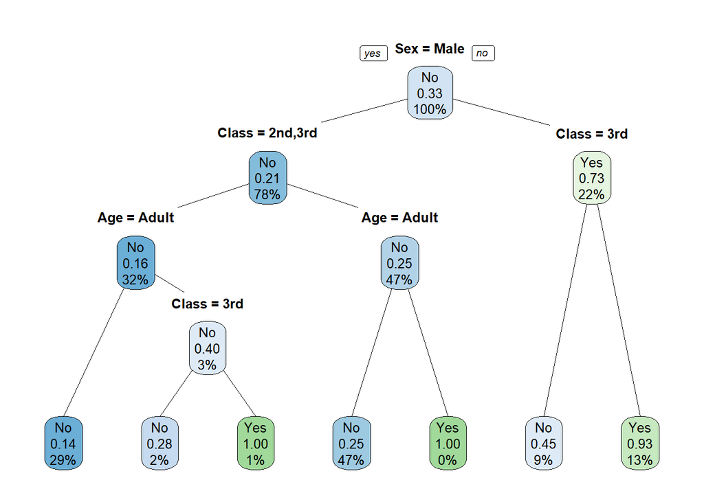

```r
library(rpart.plot)
rpart.plot(Tree.ID3,
           branch=0, # tree shape
           type = 1, # node shape
           cex=0.8, # sign size
           fallen.leaves=T)
```

### 3. Predict

#### Training

```r
# Apparent Performance
pred.ID3.train <- predict(Tree.ID3,
                    newdata=training,
                    type="class")

perform.ID3.Apparent <- ModelPerformance(pred.ID3.train, training[,Y_attribute])
## Confusion Matrix
perform.ID3.Apparent$confusion_matrix
```

```
##                  true_condition
## predict_condition   No  Yes
##               No  1315  396
##               Yes   19  250
```

```r
## Accuracy
perform.ID3.Apparent$ACC
```

```
## [1] 0.790404
```

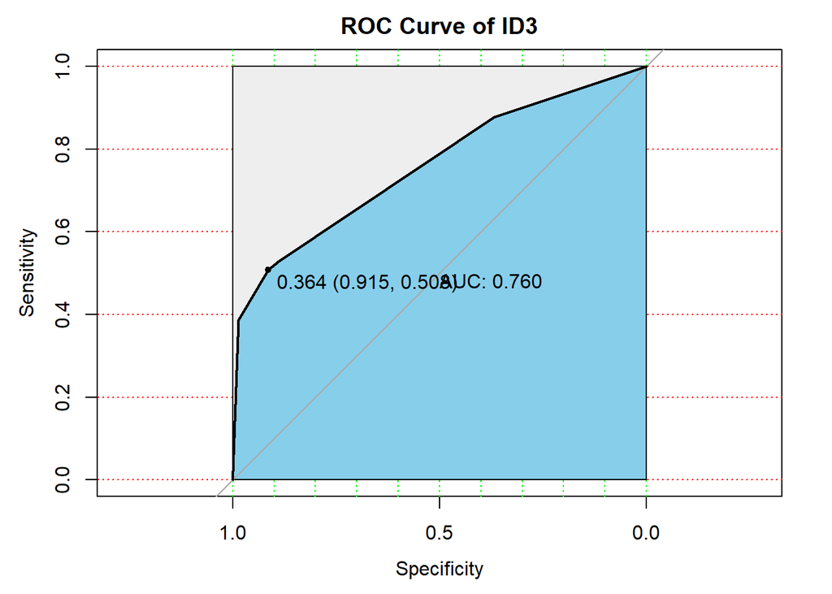

```r
library(pROC)

pred.ID3.train.prob = predict(Tree.ID3,
                         newdata=training,
                         type = "prob")


roc.ID3.train <- roc(response = training[,Y_attribute],
               predictor = pred.ID3.train.prob[,2],
               plot = T,
               print.auc=TRUE,
               auc.polygon=TRUE,
               grid=c(0.1, 0.2),
               grid.col=c("green", "red"),
               max.auc.polygon=TRUE,
               auc.polygon.col="skyblue",
               print.thres=TRUE,
               main='ROC Curve of ID3')
```

#### Testing

```r
# True Performance
pred.ID3.test <- predict(Tree.ID3,
                    newdata=testing,
                    type="class")

perform.ID3.True <- ModelPerformance(pred.ID3.test, testing[,Y_attribute])
## Confusion Matrix
perform.ID3.True$confusion_matrix
```

```
##                  true_condition
## predict_condition  No Yes
##               No  155  45
##               Yes   1  20
```

```r
## Accuracy
perform.ID3.True$ACC
```

```
## [1] 0.7918552
```

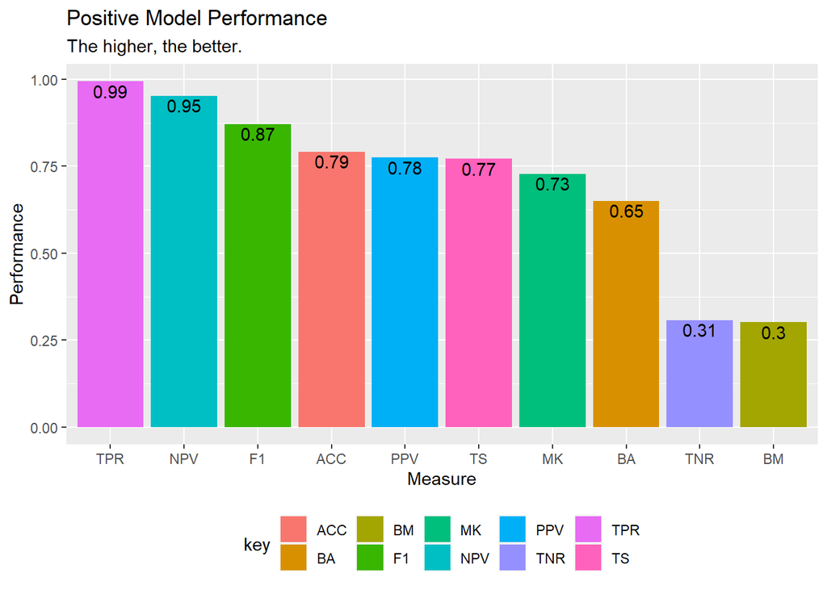

```r
perform.ID3.True$plot_positive
```

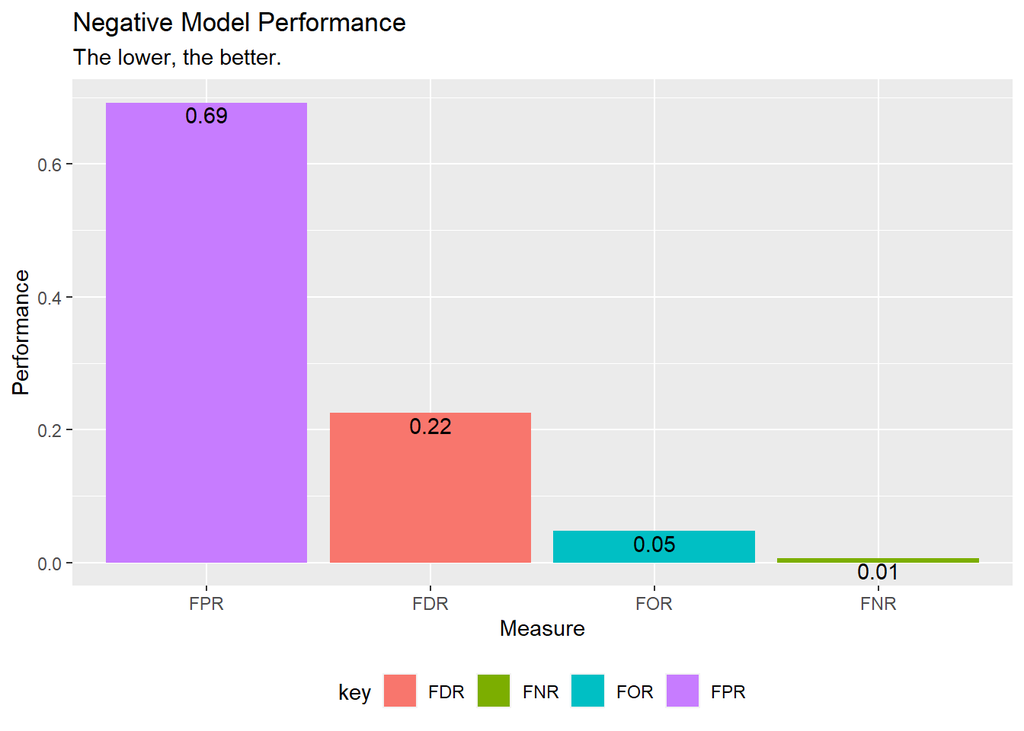

```r
perform.ID3.True$plot_negative
```